[figure not shown]

# Break Free From Plastic Report

##### Auswertung für alle Kontinente

- von `Lisa Reiber`
- *zuletzt generiert: 2022-09-16*
- *Mehr Informationen zu Break Free From Plastic finden Sie unter diesem [Link](https://www.breakfreefromplastic.org).*

### Vorwort

Im Folgenden soll der Datensatz der **Break Free From Plastic** Bewegung für das Jahr 2019 explorativ erkundet werden. Enthalten sind Informationen zu: Land, Jahr, Hersteller des Produktes, Art des gesammelten Plastiks sowie die Anzahl an durchgeführten Events und der Anzahl teilnehmender Freiwilliger.

### Datenbereinigung

Im Jahr 2020 konnten nur wenige Events durchgeführt werden. Nach Betrachtung der Datenlage wurde das Jahr 2020 deshalb von der Analyse ausgeschlossen. Auch wurde der Datensatz in zwei Tabellen aufgeteilt: Daten zum Plastikaudit und Daten aus der Gemeinschaft rund um die Bewegung. Nach der Datenbereinigung verblieben noch Daten aus 49 Ländern und zu 7128 Herstellern im Datensatz.

### 1. Aktivitäten

2019 führte Break Free From Plastics mehrere Events mit Freiwilligen durch, kategorisierte die verschiedenen Plastikstücke und sorgte im Anschluss für ihre fachgerechte Entsorgung. Besonders häufig waren Plastikstücke der Firmen La Doo, The Coca-Cola Company und Barna.

| Unternehmen | Anzahl Plastikstücke |
| --- | --- |
| La Doo | 15221 |
| The Coca-Cola Company | 9988 |
| Barna | 6225 |
| Pure Water, Inc. | 5310 |
| Nestlé | 3980 |
| Unilever | 2799 |
| PepsiCo | 2302 |
| Universal Robina Corporation | 1699 |
| Reckitt Benckiser | 1615 |
| Indofood | 1443 |

> –> Das Unternehmen mit den **meisten Plastikstücken** ist La Doo mit insgesamt 15221 Plastikstücken in 2019.

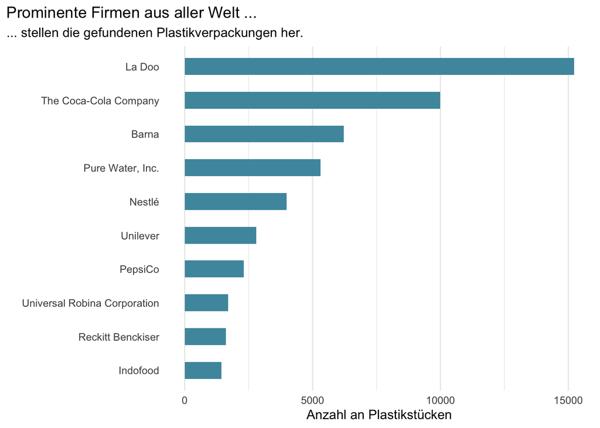

### Eindrücke

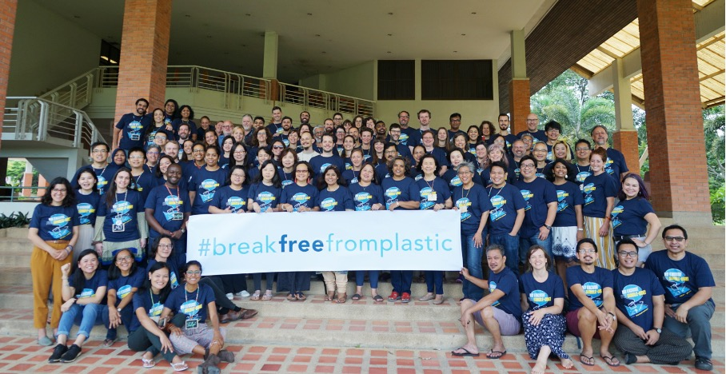

Gruppenfoto der Aktion mit ca. 100 Personen in gleichfarbigen, blauen T-Shirts die ein Plakat der Aktion #breakfreefromplastik vor sich halten.